# Technical Report

**introduction** The project utilizes a comprehensive dataset containing information on COVID-19 assessment center locations: (location name, operator, physical address, phone number, website, public health unit, latitude, longitude, hours of operation, age restrictions, appointment requirements, service modalities).

```python
import pandas as pd
```

**load the dataset** Data columns (total 45 columns)

```python
# Load the dataset
data_path = r'C:\Users\User PC\Desktop\DATA SET\assessment_centre_locations.csv'
df = pd.read_csv(data_path)
```

```python
print("Column Names:", df.columns)
```

```
Column Names: Index(['testing_enrolled', 'location_id', 'assessment_centre', 'location_name',
       'operated_by', 'city', 'address', 'address_fr', 'postal_code',
       'province', 'latitude', 'longitude', 'phu', 'phone', 'website',
       'monday', 'tuesday', 'wednesday', 'thursday', 'friday', 'appointments',
       'phone_appointments', 'symptomatic', 'drive_through', 'accessible',
       'additional_information', 'saturday', 'sunday', 'online_appointments',
       'walk_ins', 'children_under_2', 'age_threshold', 'public_transit',
       'additional_information_fr', 'location_name_fr',
       'french_language_services', 'free_parking', 'weeks_pregnant',
       'general_population', 'asl_interpretation', 'email', 'first_nations',
       'community_lab', 'vaccine_enrolled', 'pharmacy'],
      dtype='object')
```

```python
print(df.head())
```

```
   testing_enrolled  location_id  assessment_centre  \
0               1.0            1                1.0
1               NaN            2                1.0
2               NaN            3                1.0
3               NaN            4                1.0
4               1.0            5                1.0

                                   location_name  \
0                  Blanche River Health-Kirkland
1  South Georgian Bay Regional Assessment Centre
2                      Midland Assessment Centre
3                 COVID-19 Testing Clinic Milton
4           Oakville Trafalgar Memorial Hospital

                                 operated_by           city  \
```

[output cut: 35 more lines]

**Descriptive statistics** In data analysis, it is often crucial to distinguish between numerical and categorical data types. Numerical columns contain continuous or discrete numeric values, while categorical columns contain discrete categories or labels. This report details the process of separating numerical and categorical columns in the dataset and presents the identified columns.

```python
# Summary statistics of the dataset
print(df.info())
```

```
<class 'pandas.core.frame.DataFrame'>
RangeIndex: 2244 entries, 0 to 2243
Data columns (total 45 columns):
 #   Column                     Non-Null Count  Dtype
---  ------                     --------------  -----
 0   testing_enrolled           569 non-null    float64
 1   location_id                2244 non-null   int64
 2   assessment_centre          299 non-null    float64
 3   location_name              2244 non-null   object
 4   operated_by                871 non-null    object
 5   city                       2244 non-null   object
 6   address                    2241 non-null   object
 7   address_fr                 171 non-null    object
 8   postal_code                2243 non-null   object
 9   province                   2244 non-null   object
```

[output cut: 38 more lines]

**Data preparation** -For Numerical Columns: Using the select_dtypes method, I identified the following numerical columns, Columns containing continuous or discrete numeric values, typically represented by data types float64 and int64. -for Categorical Columns: Similarly, using the select_dtypes method, I identified the following categorical columns, Columns containing discrete categories or labels, typically represented by the data type object.

```python
# dividing the numerical and categorical coloms
numerical_colums = df.select_dtypes(include=['float64', 'int64']).columns
categorical_colums = df.select_dtypes(include=['object']).columns

print("Numerical Columns:")
print(numerical_colums)

print("Categorical Columns:")
print(categorical_colums)
```

```
Numerical Columns:
Index(['testing_enrolled', 'location_id', 'assessment_centre', 'latitude',
       'longitude', 'appointments', 'phone_appointments', 'symptomatic',
       'drive_through', 'accessible', 'walk_ins', 'children_under_2',
       'public_transit', 'french_language_services', 'free_parking',
       'general_population', 'asl_interpretation', 'first_nations',
       'community_lab', 'vaccine_enrolled', 'pharmacy'],
      dtype='object')
Categorical Columns:
Index(['location_name', 'operated_by', 'city', 'address', 'address_fr',
       'postal_code', 'province', 'phu', 'phone', 'website', 'monday',
       'tuesday', 'wednesday', 'thursday', 'friday', 'additional_information',
       'saturday', 'sunday', 'online_appointments', 'age_threshold',
       'additional_information_fr', 'location_name_fr', 'weeks_pregnant',
       'email'],
      dtype='object')
```

provides a detailed summary of the numerical columns in the dataset, including metrics such as count, mean, standard deviation, minimum, maximum, and quartiles (25%, 50%, 75%).

```python
print(df.describe())
```

```
       testing_enrolled   location_id  assessment_centre     latitude  \
count             569.0   2244.000000              299.0  2243.000000
mean                1.0   1733.277184                1.0    44.030448
std                 0.0   3566.862475                0.0     1.794141
min                 1.0      1.000000                1.0     0.000000
25%                 1.0    577.750000                1.0    43.483263
50%                 1.0   1148.500000                1.0    43.742139
75%                 1.0   1716.250000                1.0    44.261460
max                 1.0  23470.000000                1.0    52.922613

         longitude  appointments  phone_appointments  symptomatic  \
count  2243.000000        2210.0              2000.0        857.0
mean    -79.480883           1.0                 1.0          1.0
std       3.278385           0.0                 0.0          0.0
min     -94.522027           1.0                 1.0          1.0
25%     -80.093238           1.0                 1.0          1.0
50%     -79.511043           1.0                 1.0          1.0
75%     -79.216645           1.0                 1.0          1.0
max       0.000000           1.0                 1.0          1.0

       drive_through  accessible  ...  children_under_2  public_transit  \
count           58.0       169.0  ...             141.0           134.0
mean             1.0         1.0  ...               1.0             1.0
std              0.0         0.0  ...               0.0             0.0
min              1.0         1.0  ...               1.0             1.0
25%              1.0         1.0  ...               1.0             1.0
50%              1.0         1.0  ...               1.0             1.0
75%              1.0         1.0  ...               1.0             1.0
max              1.0         1.0  ...               1.0             1.0

       french_language_services  free_parking  general_population  \
count                      64.0         145.0                77.0
mean                        1.0           1.0                 1.0
std                         0.0           0.0                 0.0
min                         1.0           1.0                 1.0
25%                         1.0           1.0                 1.0
50%                         1.0           1.0                 1.0
75%                         1.0           1.0                 1.0
max                         1.0           1.0                 1.0

       asl_interpretation  first_nations  community_lab  vaccine_enrolled  \
count                17.0            8.0           60.0            1804.0
mean                  1.0            1.0            1.0               1.0
std                   0.0            0.0            0.0               0.0
min                   1.0            1.0            1.0               1.0
25%                   1.0            1.0            1.0               1.0
50%                   1.0            1.0            1.0               1.0
75%                   1.0            1.0            1.0               1.0
max                   1.0            1.0            1.0               1.0

       pharmacy
count    1876.0
mean        1.0
std         0.0
min         1.0
25%         1.0
50%         1.0
75%         1.0
max         1.0

[8 rows x 21 columns]
```

**Data visualization** Create visualization (histograms, bar charts, scatter plots) to understand data distributions and relationships

```python
#data visualization
#creat histograms,bar charts,scatter plots
import seaborn as sns
import matplotlib.pyplot as plt
```

**The histograms provide a comprehensive view of the distribution of numerical variables in the dataset:**

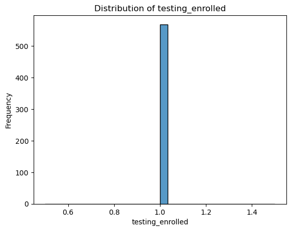

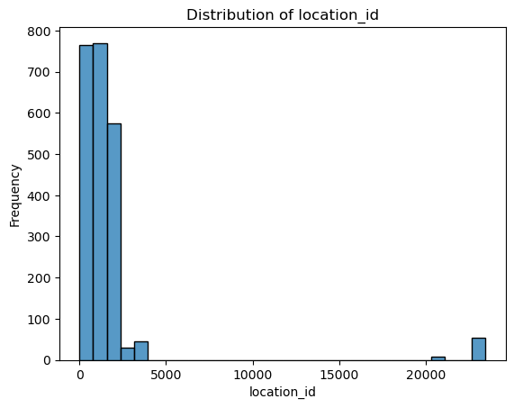

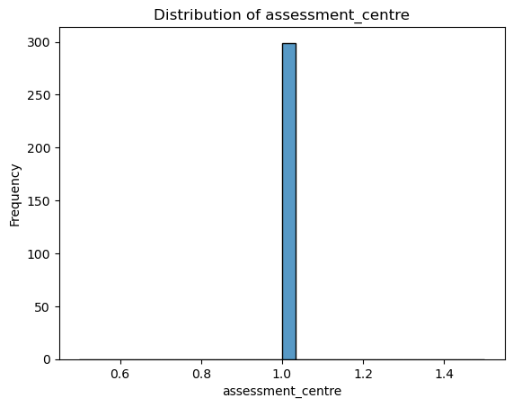

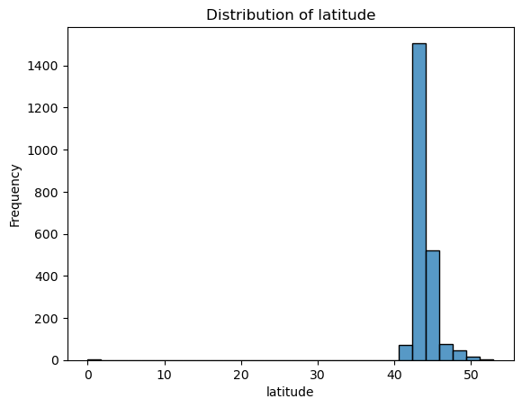

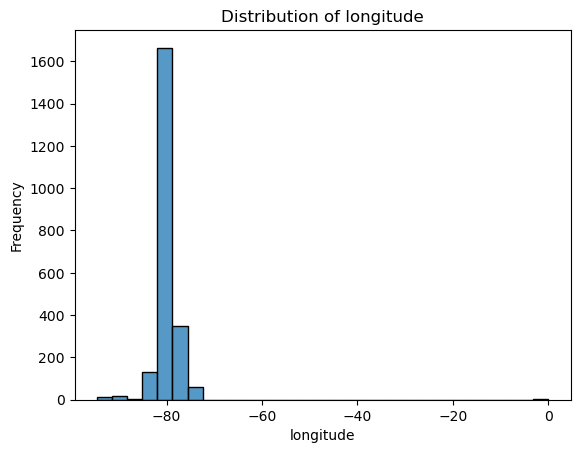

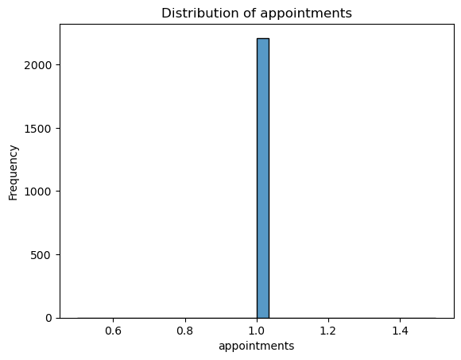

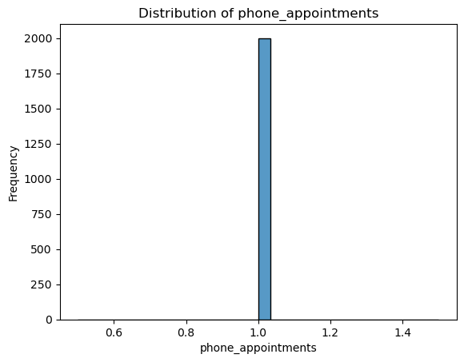

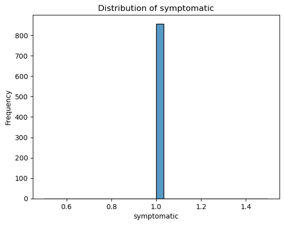

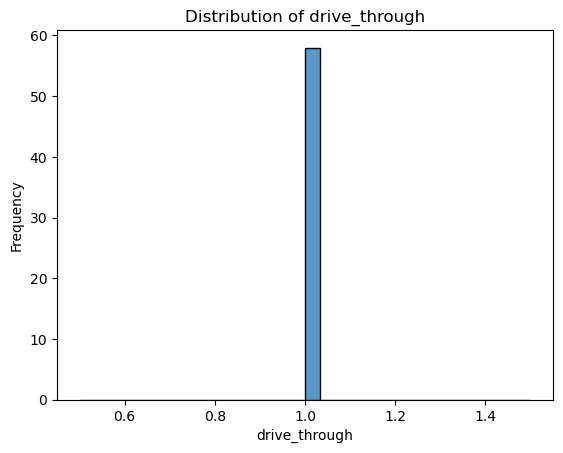

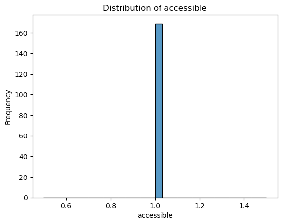

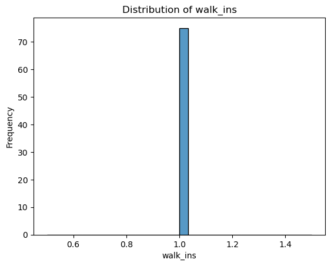

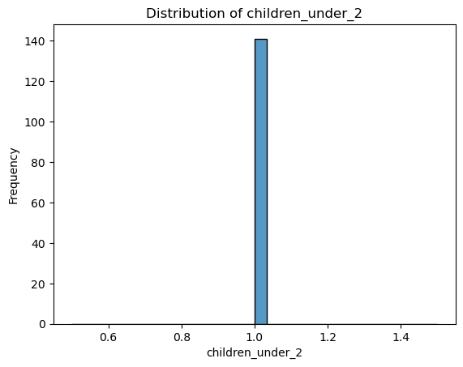

[9 more figures not shown]

```python
#Histogram of numeric variables
numeric_columss = df.select_dtypes(include=['float64', 'int64']).columns
for col in numeric_columss:
    sns.histplot(df[col].dropna(), bins=30)
    plt.title(f'Distribution of {col}')
    plt.xlabel(col)
    plt.ylabel('Frequency')
    plt.show()
```

```python
# Count the number of assessment centers in each city
city_counts = df['city'].value_counts()

# Display the city counts
print(city_counts)
```

```
Toronto        264
Mississauga    104
Ottawa          83
Brampton        73
Scarborough     73
              ...
Rainy River      1
Osgoode          1
Thessalon        1
Blind River      1
Chesley          1
Name: city, Length: 338, dtype: int64
```

```python
# Identify the top 10 cities with the most assessment centers
top_cities = city_counts.nlargest(10)

# Display the top 10 cities
print(top_cities)
```

```
Toronto        264
Mississauga    104
Ottawa          83
Brampton        73
Scarborough     73
London          63
Hamilton        56
Kitchener       43
Kingston        43
Windsor         42
Name: city, dtype: int64
```

**Bar Plot**

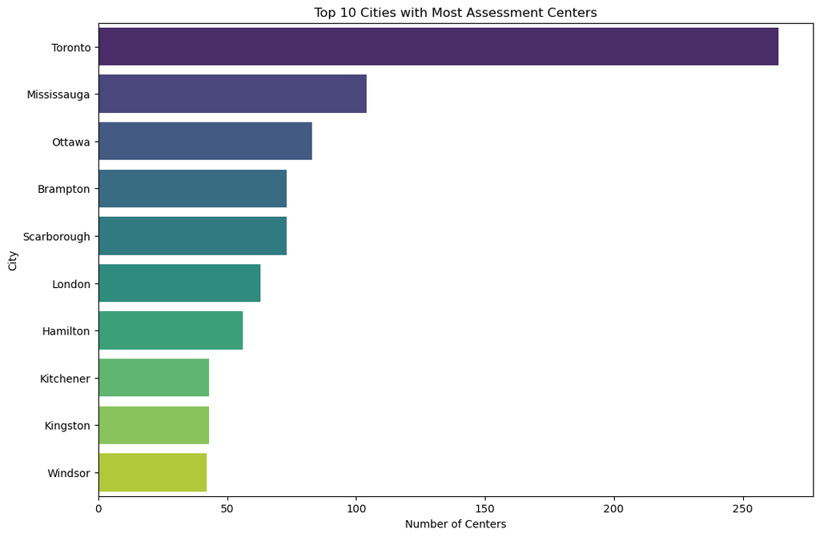

```python
# Create a bar plot for the top 10 cities
plt.figure(figsize=(12, 8))
sns.barplot(x=top_cities.values, y=top_cities.index, palette='viridis')
plt.title('Top 10 Cities with Most Assessment Centers')
plt.xlabel('Number of Centers')
plt.ylabel('City')
plt.show()
```

```python
# Count the number of assessment centers in each operated_by
operated_by_counts = df['operated_by'].value_counts()

# Display the operated_by counts
print(operated_by_counts)
```

```
Shoppers Drug Mart                   124
Shoppers                             106
Independent                          105
Rexall                                51
LifeLabs                              35
                                    ...
Chatham-Kent Health Alliance           1
Erie Shores Healthcare                 1
Guelph General Hospital                1
Hamilton Family Health Team            1
St. Thomas Elgin General Hospital      1
Name: operated_by, Length: 228, dtype: int64
```

```python
# Identify the top 10 operated_by with the most assessment centers
top_operated_by = operated_by_counts.nlargest(10)

# Display the top 10 operated_by
print(top_operated_by)
```

```
Shoppers Drug Mart    124
Shoppers              106
Independent           105
Rexall                 51
LifeLabs               35
Costco                 26
Pharmasave             17
McKesson               15
Walmart                15
Dynacare               13
Name: operated_by, dtype: int64
```

**Bar Plot**

[figure not shown]

```python
# Create a bar plot for the top 10 cities
plt.figure(figsize=(12, 8))
sns.barplot(x=top_cities.values, y=top_cities.index, palette='viridis')
plt.title('Top 10 operated_by with Most Assessment Centers')
plt.xlabel('Number of Centers')
plt.ylabel('operated_by')
plt.show()
```

```python
# Count the number of assessment centers in each appointments
appointments_counts = df['appointments'].value_counts()

# Display the appointments counts
print(appointments_counts)
```

```
1.0    2210
Name: appointments, dtype: int64
```

```python
# Identify the top 10 appointments with the most assessment centers
appointments_by = appointments_counts.nlargest(10)

# Display the top 10 appointments
print(appointments_by)
```

```
1.0    2210
Name: appointments, dtype: int64
```

**Bar Plot**

[figure not shown]

```python
# Create a bar plot for the top 10 appointments
plt.figure(figsize=(12, 8))
sns.barplot(x=top_cities.values, y=top_cities.index, palette='viridis')
plt.title('Top 10 appointments with Most Assessment Centers')
plt.xlabel('Number of Centers')
plt.ylabel('appointments')
plt.show()
```

**Scatter Plot** of Latitude vs. Longitude

I create a scatter plot to visualize the geographical distribution of COVID-19 assessment centers by plotting their latitude and longitude coordinates. The scatter plot also uses different colors to represent different cities

[figure not shown]

```python
# Create a scatter plot for latitude vs. longitude
plt.figure(figsize=(10, 6))
sns.scatterplot(x='longitude', y='latitude', data=df, hue='city', palette='viridis', s=100, alpha=0.6, edgecolor=None)
plt.title('Scatter Plot of Latitude vs Longitude')
plt.xlabel('Longitude')
plt.ylabel('Latitude')
plt.legend(title='City', bbox_to_anchor=(1.05, 1), loc='upper left')
plt.show()
```

```python
# Count the number of cities with assessment centers
cities = df['city'].nunique()
print(f'The number is: {cities}')
```

```
The number is: 338
```

```python
# Get the city names with assessment centers
cities = df['city'].unique()
print(f'The cities are:')
for city in cities:
    print(city)
```

```
The cities are:
Kirkland Lake
Collingwood
Midland
Milton
Oakville
Georgetown
Orangeville
Richmond Hill
Markham
Bracebridge
Huntsville
Orillia
Barrie
Newmarket
Alliston
Mississauga
Etobicoke
Brampton
Almonte
Brockville
Ottawa
Cornwall
Haliburton
Hawkesbury
Casselman
Rockland
Kingston
Oshawa
Ajax
Napanee
Akwesasne
Bancroft
Smiths Falls
Picton
Belleville
Trenton
Cobden
Petawawa
Pembroke
```

[output cut: 284 more lines]

```
Thorold
Wendover
Cottam
Tilbury
Vankleek Hill
Alfred
Coniston
Havelock
Port Rowan
Verona
Don Mills
Morrisburg
Minden
Russell
Chesley
```

```python
pip install pandas geopandas matplotlib
```

```python
import pandas as pd
import geopandas as gpd
import matplotlib.pyplot as plt
```

```python
df = df.dropna(subset=['latitude', 'longitude'])
```

```python
df['latitude'] = pd.to_numeric(df['latitude'], errors='coerce')
df['longitude'] = pd.to_numeric(df['longitude'], errors='coerce')
```

```python
df = df.dropna(subset=['latitude', 'longitude'])
```

```python
gdf = gpd.GeoDataFrame(df, geometry=gpd.points_from_xy(df.longitude, df.latitude))
```

```python
gdf.set_crs(epsg=4326, inplace=True)
```

|  | testing_enrolled | location_id | assessment_centre | location_name | operated_by | city | address | address_fr | postal_code | province | ... | free_parking | weeks_pregnant | general_population | asl_interpretation | email | first_nations | community_lab | vaccine_enrolled | pharmacy | geometry |
| --- | --- | --- | --- | --- | --- | --- | --- | --- | --- | --- | --- | --- | --- | --- | --- | --- | --- | --- | --- | --- | --- |
| 0 | 1.0 | 1 | 1.0 | Blanche River Health-Kirkland | Blanche River Health (Kirkland Lake site) | Kirkland Lake | 145 Government Road East | 145 chemin Government Est | P2N 3P4 | ON | ... | NaN | NaN | NaN | NaN | NaN | NaN | NaN | NaN | NaN | POINT (-80.01472 48.15355) |
| 1 | NaN | 2 | 1.0 | South Georgian Bay Regional Assessment Centre | Georgian Bay Family Health Team | Collingwood | 490 Ontario Street | NaN | L9Y 1N6 | ON | ... | NaN | NaN | NaN | NaN | NaN | NaN | NaN | NaN | NaN | POINT (-80.20152 44.50393) |
| 2 | NaN | 3 | 1.0 | Midland Assessment Centre | Georgian Bay General Hospital | Midland | 1156 St. Andrews Drive | NaN | L4R 4P4 | ON | ... | 1.0 | NaN | NaN | NaN | NaN | NaN | NaN | NaN | NaN | POINT (-79.91246 44.74184) |
| 3 | NaN | 4 | 1.0 | COVID-19 Testing Clinic Milton | FH Health | Milton | 725 Bronte Street South | 725 rue Bronte Sud | L9T 9K1 | ON | ... | 1.0 | NaN | NaN | NaN | NaN | NaN | NaN | NaN | NaN | POINT (-79.86848 43.49742) |
| 4 | 1.0 | 5 | 1.0 | Oakville Trafalgar Memorial Hospital | Halton Healthcare Services | Oakville | 3001 Hospital Gate | 3001 Hospital Gate | L6M 0L8 | ON | ... | 1.0 | NaN | NaN | NaN | NaN | NaN | NaN | NaN | NaN | POINT (-79.76393 43.45087) |
| ... | ... | ... | ... | ... | ... | ... | ... | ... | ... | ... | ... | ... | ... | ... | ... | ... | ... | ... | ... | ... | ... |
| 2239 | NaN | 2165 | NaN | Rexall | NaN | Brantford | 260 St. Paul Avenue | NaN | N3R 4M7 | ON | ... | NaN | NaN | NaN | NaN | NaN | NaN | NaN | 1.0 | 1.0 | POINT (-80.27712 43.15294) |
| 2240 | NaN | 2166 | NaN | Rexall | NaN | Hamilton | 234 Parkdale Avenue North | NaN | L8H 5X5 | ON | ... | NaN | NaN | NaN | NaN | NaN | NaN | NaN | 1.0 | 1.0 | POINT (-79.78883 43.24296) |
| 2241 | NaN | 2167 | NaN | Rexall | NaN | Ottawa | 1190 Wellington Street | NaN | K1Y 2Z5 | ON | ... | NaN | NaN | NaN | NaN | NaN | NaN | NaN | 1.0 | 1.0 | POINT (-75.72948 45.40042) |
| 2242 | NaN | 2168 | NaN | Shoppers Simply Pharmacy | NaN | Toronto | 1223 St. Clair Avenue West, Unit 1221 | NaN | M6E 1B5 | ON | ... | NaN | NaN | NaN | NaN | NaN | NaN | NaN | 1.0 | 1.0 | POINT (-79.44501 43.67723) |
| 2243 | NaN | 2169 | NaN | Northview Remedy's Rx | NaN | Brantford | 222 Fairview Drive | NaN | N3R 2W9 | ON | ... | NaN | NaN | NaN | NaN | NaN | NaN | NaN | 1.0 | 1.0 | POINT (-80.26136 43.16982) |

2243 rows × 46 columns

```python
# Remove outliers based on unrealistic coordinates
# Ontario's coordinates roughly range between latitudes 41 to 56 and longitudes -95 to -74
df = df[(df['latitude'] >= 41) & (df['latitude'] <= 56) & (df['longitude'] >= -95) & (df['longitude'] <= -74)]
```

```python
# Create a GeoDataFrame
gdf = gpd.GeoDataFrame(df, geometry=gpd.points_from_xy(df.longitude, df.latitude))
```

```python
# Set the coordinate reference system (CRS) to WGS84 (EPSG:4326)
gdf.set_crs(epsg=4326, inplace=True)
```

|  | testing_enrolled | location_id | assessment_centre | location_name | operated_by | city | address | address_fr | postal_code | province | ... | free_parking | weeks_pregnant | general_population | asl_interpretation | email | first_nations | community_lab | vaccine_enrolled | pharmacy | geometry |
| --- | --- | --- | --- | --- | --- | --- | --- | --- | --- | --- | --- | --- | --- | --- | --- | --- | --- | --- | --- | --- | --- |
| 0 | 1.0 | 1 | 1.0 | Blanche River Health-Kirkland | Blanche River Health (Kirkland Lake site) | Kirkland Lake | 145 Government Road East | 145 chemin Government Est | P2N 3P4 | ON | ... | NaN | NaN | NaN | NaN | NaN | NaN | NaN | NaN | NaN | POINT (-80.01472 48.15355) |
| 1 | NaN | 2 | 1.0 | South Georgian Bay Regional Assessment Centre | Georgian Bay Family Health Team | Collingwood | 490 Ontario Street | NaN | L9Y 1N6 | ON | ... | NaN | NaN | NaN | NaN | NaN | NaN | NaN | NaN | NaN | POINT (-80.20152 44.50393) |
| 2 | NaN | 3 | 1.0 | Midland Assessment Centre | Georgian Bay General Hospital | Midland | 1156 St. Andrews Drive | NaN | L4R 4P4 | ON | ... | 1.0 | NaN | NaN | NaN | NaN | NaN | NaN | NaN | NaN | POINT (-79.91246 44.74184) |
| 3 | NaN | 4 | 1.0 | COVID-19 Testing Clinic Milton | FH Health | Milton | 725 Bronte Street South | 725 rue Bronte Sud | L9T 9K1 | ON | ... | 1.0 | NaN | NaN | NaN | NaN | NaN | NaN | NaN | NaN | POINT (-79.86848 43.49742) |
| 4 | 1.0 | 5 | 1.0 | Oakville Trafalgar Memorial Hospital | Halton Healthcare Services | Oakville | 3001 Hospital Gate | 3001 Hospital Gate | L6M 0L8 | ON | ... | 1.0 | NaN | NaN | NaN | NaN | NaN | NaN | NaN | NaN | POINT (-79.76393 43.45087) |
| ... | ... | ... | ... | ... | ... | ... | ... | ... | ... | ... | ... | ... | ... | ... | ... | ... | ... | ... | ... | ... | ... |
| 2239 | NaN | 2165 | NaN | Rexall | NaN | Brantford | 260 St. Paul Avenue | NaN | N3R 4M7 | ON | ... | NaN | NaN | NaN | NaN | NaN | NaN | NaN | 1.0 | 1.0 | POINT (-80.27712 43.15294) |
| 2240 | NaN | 2166 | NaN | Rexall | NaN | Hamilton | 234 Parkdale Avenue North | NaN | L8H 5X5 | ON | ... | NaN | NaN | NaN | NaN | NaN | NaN | NaN | 1.0 | 1.0 | POINT (-79.78883 43.24296) |
| 2241 | NaN | 2167 | NaN | Rexall | NaN | Ottawa | 1190 Wellington Street | NaN | K1Y 2Z5 | ON | ... | NaN | NaN | NaN | NaN | NaN | NaN | NaN | 1.0 | 1.0 | POINT (-75.72948 45.40042) |
| 2242 | NaN | 2168 | NaN | Shoppers Simply Pharmacy | NaN | Toronto | 1223 St. Clair Avenue West, Unit 1221 | NaN | M6E 1B5 | ON | ... | NaN | NaN | NaN | NaN | NaN | NaN | NaN | 1.0 | 1.0 | POINT (-79.44501 43.67723) |
| 2243 | NaN | 2169 | NaN | Northview Remedy's Rx | NaN | Brantford | 222 Fairview Drive | NaN | N3R 2W9 | ON | ... | NaN | NaN | NaN | NaN | NaN | NaN | NaN | 1.0 | 1.0 | POINT (-80.26136 43.16982) |

2241 rows × 46 columns

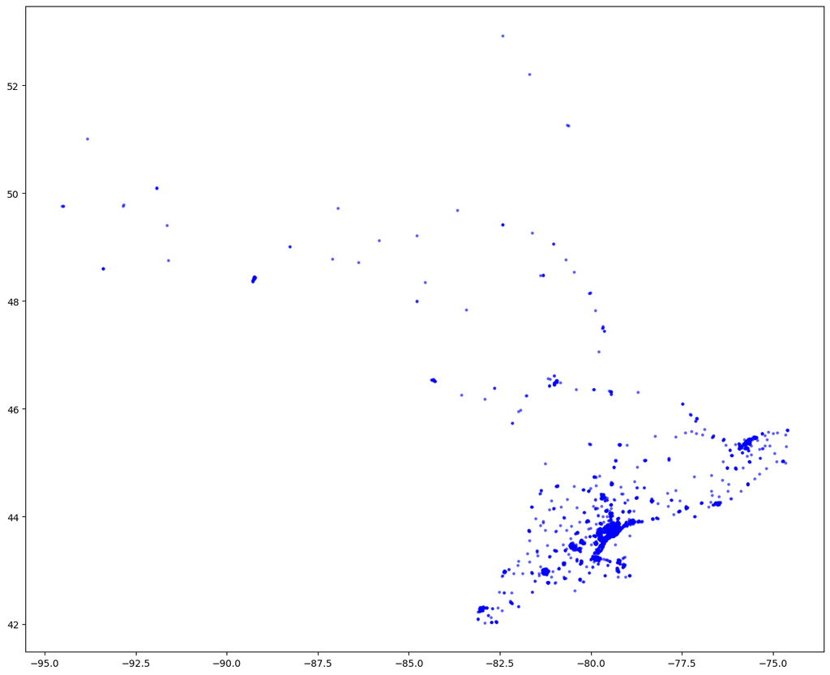

```python
# Plot the geographical distribution with a base map
fig, ax = plt.subplots(1, 1, figsize=(15, 15))
gdf.plot(ax=ax, color='blue', markersize=5, alpha=0.5)
```

```python
# Customize the plot
ax.set_title('Geographical Distribution of COVID-19 Assessment Centers in Ontario', fontsize=15)
ax.set_xlabel('Longitude', fontsize=12)
ax.set_ylabel('Latitude', fontsize=12)
```

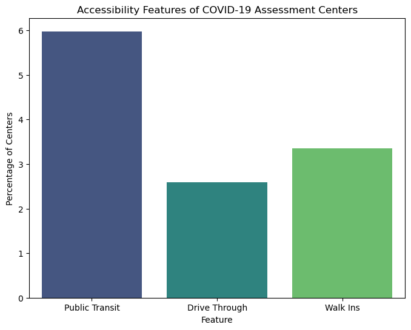

```python
import pandas as pd
import matplotlib.pyplot as plt
import seaborn as sns

# Assuming df is your DataFrame with the necessary columns
accessibility_features = {
    'Public Transit': df['public_transit'].fillna(0).astype(int).sum() / len(df) * 100,
    'Drive Through': df['drive_through'].fillna(0).astype(int).sum() / len(df) * 100,
    'Walk Ins': df['walk_ins'].fillna(0).astype(int).sum() / len(df) * 100
}

# Plot bar chart
plt.figure(figsize=(8, 6))
sns.barplot(x=list(accessibility_features.keys()), y=list(accessibility_features.values()), palette='viridis')
plt.title('Accessibility Features of COVID-19 Assessment Centers')
plt.xlabel('Feature')
plt.ylabel('Percentage of Centers')
plt.show()
```

```python
# Calculate percentages of centers accessible by public transit, drive-through, and walk-ins
public_transit_accessible = df['public_transit'].sum() / len(df) * 100
drive_through_available = df['drive_through'].sum() / len(df) * 100
walk_ins_available = df['walk_ins'].sum() / len(df) * 100

print(f"Percentage of centers accessible by public transit: {public_transit_accessible:.2f}%")
print(f"Percentage of centers offering drive-through: {drive_through_available:.2f}%")
print(f"Percentage of centers allowing walk-ins: {walk_ins_available:.2f}%")
```

```
Percentage of centers accessible by public transit: 5.98%
Percentage of centers offering drive-through: 2.59%
Percentage of centers allowing walk-ins: 3.35%
```

[figure not shown]

```python
region_summary = df.groupby('city').agg({
    'public_transit': 'mean',
    'drive_through': 'mean',
    'walk_ins': 'mean'
}).reset_index()

# Visualization: Bar chart to compare accessibility features by city
plt.figure(figsize=(12, 6))
plt.bar(region_summary['city'], region_summary['public_transit'], color='blue', label='Public Transit Access')
plt.bar(region_summary['city'], region_summary['drive_through'], color='green', label='Drive-through Access')
plt.bar(region_summary['city'], region_summary['walk_ins'], color='orange', label='Walk-in Access')
plt.xlabel('city')
plt.ylabel('Percentage')
plt.title('Accessibility Features of COVID-19 Assessment Centers by City')
plt.legend()
plt.xticks(rotation=45)
plt.tight_layout()
plt.show()
```

Data cleaning and Preprocessing

**Data cleaning and Preprocessing**

Missing data analysis the summary of the number of missing values

```python
print(df.isnull().sum())
```

```
testing_enrolled             1674
location_id                     0
assessment_centre            1944
location_name                   0
operated_by                  1373
city                            0
address                         0
address_fr                   2070
postal_code                     0
province                        0
latitude                        0
longitude                       0
phu                             0
phone                        1047
website                       159
monday                        107
tuesday                       109
wednesday                     104
thursday                      115
friday                        119
appointments                   34
phone_appointments            242
symptomatic                  1386
drive_through                2183
accessible                   2072
additional_information       1904
saturday                      192
sunday                        294
online_appointments           312
walk_ins                     2166
children_under_2             2100
age_threshold                1489
public_transit               2107
additional_information_fr    2182
location_name_fr             2050
french_language_services     2177
free_parking                 2096
weeks_pregnant               2239
general_population           2164
asl_interpretation           2224
email                        2223
first_nations                2233
community_lab                2181
vaccine_enrolled              437
pharmacy                      365
dtype: int64
```

**Check the Duplicates**

Number of duplicate rows: 0 (There is no duplicate in the dataset)

```python
# Check for duplicate rows
duplicates = df.duplicated()

# Print the number of duplicate rows
print(f'Number of duplicate rows: {duplicates.sum()}')
```

```
Number of duplicate rows: 0
```

**Outliers**

From the outlier analysis, we observed that certain columns in the dataset have a significant number of outliers Below is a detailed summary of the findings:

```
Number of outliers in testing_enrolled: 0
Number of outliers in location_id: 86
     location_id
281         3432
282         3433
283         3434
284         3442
285         3452
..           ...
363        21077
364        22888
365        22889
366        22890
367        22891

[86 rows x 1 columns]
Number of outliers in assessment_centre: 0
Number of outliers in latitude: 278
       latitude
0     48.153552
25    45.431716
27    45.603834
29    45.544511
39    45.432380
...         ...
2219  46.453224
2222  45.445700
2224  50.098194
2231  46.451610
2234  49.012059

[278 rows x 1 columns]
Number of outliers in longitude: 554
      longitude
20   -76.189452
21   -75.696870
22   -75.653503
23   -75.690478
24   -74.718358
...         ...
```

[output cut: 8 more lines]

```
Number of outliers in phone_appointments: 0
Number of outliers in symptomatic: 0
Number of outliers in drive_through: 0
Number of outliers in accessible: 0
Number of outliers in walk_ins: 0
Number of outliers in children_under_2: 0
Number of outliers in public_transit: 0
Number of outliers in french_language_services: 0
Number of outliers in free_parking: 0
Number of outliers in general_population: 0
Number of outliers in asl_interpretation: 0
Number of outliers in first_nations: 0
Number of outliers in community_lab: 0
Number of outliers in vaccine_enrolled: 0
Number of outliers in pharmacy: 0
```

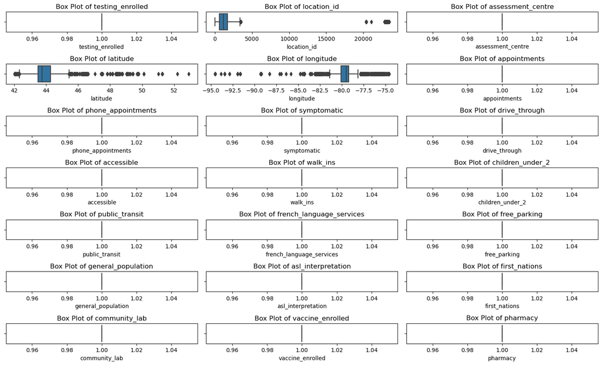

```python
# Select numerical columns
numerical_cols = df.select_dtypes(include=['float64', 'int64']).columns

# using IQR to detect outliers
def detect_outliers_iqr(df, column):
    Q1 = df[column].quantile(0.25)
    Q3 = df[column].quantile(0.75)
    IQR = Q3 - Q1
    lower_bound = Q1 - 1.5 * IQR
    upper_bound = Q3 + 1.5 * IQR
    outliers = df[(df[column] < lower_bound) | (df[column] > upper_bound)]
    return outliers

# Check for outliers in each numerical column
for col in numerical_cols:
    outliers = detect_outliers_iqr(df, col)
    print(f'Number of outliers in {col}: {len(outliers)}')
    if len(outliers) > 0:
        print(outliers[[col]])

# box plots the outliers
plt.figure(figsize=(15, 10))
for i, col in enumerate(numerical_cols, 1):
    plt.subplot(len(numerical_cols) // 3 + 1, 3, i)
    sns.boxplot(x=df[col])
    plt.title(f'Box Plot of {col}')
plt.tight_layout()
plt.show()
```

**Attributes with a percentage of missing values**

```python
# Calculate the number of missing values for each column
missing_values = df.isnull().sum()

# Calculate the percentage of missing values for each column
missing_percentage = (missing_values / len(df)) * 100

# Create a DataFrame to hold the results
missing_data = pd.DataFrame({
    'Missing Values': missing_values,
    'Percentage': missing_percentage
})

# Display the missing data DataFrame
print(missing_data)
```

```
                           Missing Values  Percentage
testing_enrolled                     1674   74.698795
location_id                             0    0.000000
assessment_centre                    1944   86.746988
location_name                           0    0.000000
operated_by                          1373   61.267291
city                                    0    0.000000
address                                 0    0.000000
address_fr                           2070   92.369478
postal_code                             0    0.000000
province                                0    0.000000
latitude                                0    0.000000
longitude                               0    0.000000
phu                                     0    0.000000
phone                                1047   46.720214
website                               159    7.095047
monday                                107    4.774654
tuesday                               109    4.863900
wednesday                             104    4.640785
thursday                              115    5.131638
friday                                119    5.310129
appointments                           34    1.517180
phone_appointments                    242   10.798751
symptomatic                          1386   61.847390
drive_through                        2183   97.411870
accessible                           2072   92.458724
additional_information               1904   84.962071
saturday                              192    8.567604
sunday                                294   13.119143
online_appointments                   312   13.922356
walk_ins                             2166   96.653280
children_under_2                     2100   93.708166
age_threshold                        1489   66.443552
public_transit                       2107   94.020527
additional_information_fr            2182   97.367247
location_name_fr                     2050   91.477019
french_language_services             2177   97.144132
free_parking                         2096   93.529674
weeks_pregnant                       2239   99.910754
general_population                   2164   96.564034
asl_interpretation                   2224   99.241410
email                                2223   99.196787
first_nations                        2233   99.643017
community_lab                        2181   97.322624
vaccine_enrolled                      437   19.500223
pharmacy                              365   16.287372
```

**High Missing Data**

-Attributes with a top 10 percentage of missing values (over 90%) need careful consideration. -The high percentage of missing data in certain attributes indicates potential issues with data collection or relevance.

```python
# Sort the DataFrame by the number of missing values in descending order
missing_data_sorted = missing_data.sort_values(by='Missing Values', ascending=False)

# Display the top attributes with the most missing data
print(missing_data_sorted.head(10))
```

```
                           Missing Values  Percentage
weeks_pregnant                       2239   99.910754
first_nations                        2233   99.643017
asl_interpretation                   2224   99.241410
email                                2223   99.196787
drive_through                        2183   97.411870
additional_information_fr            2182   97.367247
community_lab                        2181   97.322624
french_language_services             2177   97.144132
walk_ins                             2166   96.653280
general_population                   2164   96.564034
```

**Handling Missing Data**

1-Missing values in numerical columns were filled with the mean of each respective column. 2-For categorical columns, missing values were filled with the mode (most frequent value) of each column. 3-Columns with more than 96% missing data were identified and removed from the dataset(drop the colums).

```python
#data cleaning and preparation
# Fill missing numerical values with the mean
for column in df.select_dtypes(include=['float64', 'int64']).columns:
    df[column].fillna(df[column].mean(), inplace=True)
```

```python
#Display missing values after filling
print("\nMissing values after filling:")
print(df[numerical_cols].isnull().sum())
```

```
Missing values after filling:
testing_enrolled            0
location_id                 0
assessment_centre           0
latitude                    0
longitude                   0
appointments                0
phone_appointments          0
symptomatic                 0
drive_through               0
accessible                  0
walk_ins                    0
children_under_2            0
public_transit              0
french_language_services    0
free_parking                0
general_population          0
asl_interpretation          0
first_nations               0
community_lab               0
vaccine_enrolled            0
pharmacy                    0
dtype: int64
```

```python
# Fill missing categorical values with the mode
for column in df.select_dtypes(include=['object']).columns:
    df[column].fillna(df[column].mode()[0], inplace=True)
```

```python
#Display missing values after filling
print("\nMissing values after filling:")
print(df[categorical_colums].isnull().sum())
```

```
Missing values after filling:
location_name                0
operated_by                  0
city                         0
address                      0
address_fr                   0
postal_code                  0
province                     0
phu                          0
phone                        0
website                      0
monday                       0
tuesday                      0
wednesday                    0
thursday                     0
friday                       0
additional_information       0
saturday                     0
sunday                       0
online_appointments          0
age_threshold                0
additional_information_fr    0
location_name_fr             0
weeks_pregnant               0
email                        0
dtype: int64
```

```python
# Set the threshold for missing values
threshold = 96.0
```

```python
# Identify columns to drop
columns_to_drop = missing_data[missing_data['Percentage'] > threshold].index
```

```python
# Display the columns to drop
print("Columns to be dropped due to high missing values:")
print(columns_to_drop)
```

```
Columns to be dropped due to high missing values:
Index(['drive_through', 'walk_ins', 'additional_information_fr',
       'french_language_services', 'weeks_pregnant', 'general_population',
       'asl_interpretation', 'email', 'first_nations', 'community_lab'],
      dtype='object')
```

```python
# Drop the identified columns
df_cleaned = df.drop(columns=columns_to_drop)
# Display the first few rows of the cleaned DataFrame
print("Data preview after dropping columns with high missing values:")
print(df_cleaned.head())
```

```
Data preview after dropping columns with high missing values:
   testing_enrolled  location_id  assessment_centre  \
0               1.0            1                1.0
1               1.0            2                1.0
2               1.0            3                1.0
3               1.0            4                1.0
4               1.0            5                1.0

                                   location_name  \
0                  Blanche River Health-Kirkland
1  South Georgian Bay Regional Assessment Centre
2                      Midland Assessment Centre
3                 COVID-19 Testing Clinic Milton
4           Oakville Trafalgar Memorial Hospital

```

[output cut: 43 more lines]

```python
# Calculate the number of columns before and after dropping
num_columns_before = df.shape[1]
num_columns_after = df_cleaned.shape[1]
num_columns_dropped = num_columns_before - num_columns_after
# Display the number of dropped columns
print(f'Number of columns dropped due to high missing values: {num_columns_dropped}')
```

```
Number of columns dropped due to high missing values: 10
```

```python
# Check for duplicates
print(df.duplicated().sum())
```

```
0
```

**Outliers**

to Handling Outliers i remove outliers for columns with significant outliers

```python
# Handling Outliers

# Define a function to remove outliers using the IQR method
def remove_outliers_iqr(df, column):
    Q1 = df[column].quantile(0.25)
    Q3 = df[column].quantile(0.75)
    IQR = Q3 - Q1
    lower_bound = Q1 - 1.5 * IQR
    upper_bound = Q3 + 1.5 * IQR
    df_filtered = df[(df[column] >= lower_bound) & (df[column] <= upper_bound)]
    return df_filtered

# Remove outliers for columns with significant outliers

df_no_outliers = df.copy()
df_no_outliers = remove_outliers_iqr(df_no_outliers, 'location_id')
df_no_outliers = remove_outliers_iqr(df_no_outliers, 'latitude')
df_no_outliers = remove_outliers_iqr(df_no_outliers, 'longitude')
```

**the cleaned dataset**

```python
# Save the cleaned dataset
df.to_csv('cleaned_assessment_centre_locations.csv', index=False)
print("Dataset saved successfully.")
```

```
Dataset saved successfully.
```

```python
# Load the cleaned dataset
df.to_csv('cleaned_assessment_centre_locations.csv')
```

```python
print(df.head())
```

```
   testing_enrolled  location_id  assessment_centre  \
0               1.0            1                1.0
1               1.0            2                1.0
2               1.0            3                1.0
3               1.0            4                1.0
4               1.0            5                1.0

                                   location_name  \
0                  Blanche River Health-Kirkland
1  South Georgian Bay Regional Assessment Centre
2                      Midland Assessment Centre
3                 COVID-19 Testing Clinic Milton
4           Oakville Trafalgar Memorial Hospital

                                 operated_by           city  \
```

[output cut: 35 more lines]

**Modeling**

-using these numerical attributes,showing that the MSE and R-squared values for the **linear regression model**. Lower MSE values indicate better predictive performance, while higher R-squared values indicate a better fit of the model to the data.

```python
import pandas as pd
import numpy as np
from sklearn.model_selection import train_test_split
import seaborn as sns
import matplotlib.pyplot as plt
from sklearn.preprocessing import StandardScaler
from sklearn.linear_model import LinearRegression
from sklearn.tree import DecisionTreeRegressor
from sklearn.metrics import mean_squared_error, r2_score
from sklearn.ensemble import RandomForestRegressor


# Load the dataset
df = pd.read_csv('cleaned_assessment_centre_locations.csv')
```

```python
X = df[['testing_enrolled', 'location_id', 'latitude', 'longitude', 'appointments',
        'phone_appointments', 'symptomatic', 'drive_through', 'accessible',
        'walk_ins', 'children_under_2', 'public_transit', 'french_language_services',
        'free_parking', 'general_population', 'asl_interpretation', 'first_nations',
        'community_lab', 'vaccine_enrolled', 'pharmacy']]
```

```python
y = df['latitude']  # target column name
```

```python
# Splitting data into training and testing sets (80% train, 20% test)
X_train, X_test, y_train, y_test = train_test_split(X, y, test_size=0.2, random_state=42)
```

```python
# Standardize the features
scaler = StandardScaler()
X_train_scaled = scaler.fit_transform(X_train)
X_test_scaled = scaler.transform(X_test)
```

```python
# 1. Linear Regression
lr_model = LinearRegression()
lr_model.fit(X_train_scaled, y_train)
lr_pred = lr_model.predict(X_test_scaled)
lr_mse = mean_squared_error(y_test, lr_pred)
lr_r2 = r2_score(y_test, lr_pred)

print("Linear Regression MSE:", lr_mse)
print("Linear Regression R-squared:", lr_r2)
```

```
Linear Regression MSE: 5.048709793414476e-29
Linear Regression R-squared: 1.0
```

```python
# 2. Decision Tree Regression
dt_model = DecisionTreeRegressor(random_state=42)
dt_model.fit(X_train, y_train)
dt_pred = dt_model.predict(X_test)
dt_mse = mean_squared_error(y_test, dt_pred)
dt_r2 = r2_score(y_test, dt_pred)

print("Decision Tree Regression MSE:", dt_mse)
print("Decision Tree Regression R-squared:", dt_r2)
```

```
Decision Tree Regression MSE: 3.1950510427741724e-05
Decision Tree Regression R-squared: 0.9999743867668272
```

```python
# 3. Random Forest Regression
rf_model = RandomForestRegressor(random_state=42)
rf_model.fit(X_train, y_train)
rf_pred = rf_model.predict(X_test)
rf_mse = mean_squared_error(y_test, rf_pred)
rf_r2 = r2_score(y_test, rf_pred)

print("Random Forest Regression MSE:", rf_mse)
print("Random Forest Regression R-squared:", rf_r2)
```

```
Random Forest Regression MSE: 3.0713656750996857e-05
Random Forest Regression R-squared: 0.9999753782946994
```